# Adaptive Mixed-Model Selection Report (v2.0)

Evidence-based model selection: Gaussian LMM / Gamma GLMM / Log-normal LMM, scored jointly against configurable weighted criteria

2026-08-06

## Overview

This report walks through the v2.0 evidence-based model-selection engine applied to each measurement variable. Instead of a sequential decision tree, every structurally feasible candidate (Gaussian LMM always; Gamma GLMM and Log-normal LMM additionally if the response is strictly positive) is fitted and evaluated independently. Any fixed-slope candidate whose primary residual diagnostic fails is also refit with random slopes and, if that refit converges and is non-singular, scored alongside the rest as an independent candidate. Every surviving candidate accumulates evidence from raw-data characteristics, model performance (R²/ICC), residual diagnostics, and fit stability, weighted according to `model_selection_weights` (see `scoring.R`); the candidate with the highest total evidence score is selected for downstream inference. Hard exclusions (non-convergence, singularity, structural infeasibility) are the only reason a candidate is dropped outright - residual diagnostics are weighted evidence, never a pass/fail gate.

### Final model chosen per measurement

| Measurement | Final_family | Formula | Status |
| --- | --- | --- | --- |
| mean_int | Gamma GLMM (Fixed slopes (random intercept only)) | `mean_int` ~ `treatment_layer` + (1 &#124; `ablation_id`) | OK |

## 1. Raw data assessment

### Sample sizes

Per-group and total complete-case sample sizes actually used for fitting (after removing rows with missing values in the response, treatment, or grouping variables), computed once per measurement before any per-family positivity filtering.

| Measurement | Group | N |
| --- | --- | --- |
| mean_int | control_inner | 10 |
| mean_int | control_middle | 10 |
| mean_int | control_outer | 10 |
| mean_int | control_sum | 10 |
| mean_int | laser_inner | 21 |
| mean_int | laser_middle | 21 |
| mean_int | laser_outer | 21 |
| mean_int | laser_sum | 21 |
| mean_int | Total | 124 |

Distributional characteristics of each response variable, computed once before any model is fitted. `Best_empirical_fit` is the distribution (Normal/Gamma/Log-normal) with the highest Akaike weight from a structure-free `fitdistrplus` fit on the raw values - informative prior evidence, not the inferential model itself.

| Measurement | N | Mean | SD | CV | Skewness | Kurtosis_excess | Strictly_positive | Right_skewed | Heavy_tailed | Best_empirical_fit |
| --- | --- | --- | --- | --- | --- | --- | --- | --- | --- | --- |
| mean_int | 124 | 21.7974 | 13.4909 | 0.6189 | 0.4698 | -0.6077 | TRUE | FALSE | FALSE | gamma |

## 2. Candidate models

Every candidate that was fitted per measurement (including any random-slopes rescue attempts), whether it converged, whether it was singular, and - if excluded - why. Only structural failures lead to exclusion here; a candidate with poor residual diagnostics is NOT excluded, it simply scores lower in Section 5.

| Measurement | Candidate | Converged | Singular | Excluded | Reason |
| --- | --- | --- | --- | --- | --- |
| mean_int | Gaussian LMM (Fixed slopes (random intercept only)) | TRUE | FALSE | FALSE | NA |
| mean_int | Gamma GLMM (Fixed slopes (random intercept only)) | TRUE | FALSE | FALSE | NA |
| mean_int | Log-normal LMM (Fixed slopes (random intercept only)) | TRUE | FALSE | FALSE | NA |

## 3. Model performance

AIC, BIC, marginal R², conditional R², and ICC for every non-excluded candidate. Log-normal AIC/BIC include the Jacobian correction so they are comparable to Gaussian/Gamma on the response scale. These metrics feed the evidence score in Section 5 (R²/ICC directly; AIC/BIC are reported here for context but are not themselves weighted criteria - see the raw-data “empirical fit” evidence in Section 1/5 instead).

| Measurement | Candidate | Excluded | AIC | BIC | Marginal_R2 | Conditional_R2 | ICC |
| --- | --- | --- | --- | --- | --- | --- | --- |
| mean_int | Gaussian LMM (Fixed slopes (random intercept only)) | FALSE | 824.58 | 852.78 | 0.5444 | 0.7690 | 0.4930 |
| mean_int | Gamma GLMM (Fixed slopes (random intercept only)) | FALSE | 845.82 | 874.03 | 0.6416 | 0.7322 | 0.2527 |
| mean_int | Log-normal LMM (Fixed slopes (random intercept only)) | FALSE | 872.67 | 900.87 | 0.5470 | 0.7728 | 0.4984 |

## 4. Residual diagnostics

Shapiro-Wilk (Gaussian candidates) or DHARMa KS-uniformity / dispersion / outlier tests (Gamma & Log-normal candidates), for every non-excluded candidate. `DHARMa_Seed` is the random seed drawn for that candidate’s simulation - no seed is fixed across runs, but recording it here means this exact result can be reproduced later by calling `set.seed()` with that value before re-fitting.

| Measurement | Candidate | Excluded | Shapiro_W | Shapiro_p | DHARMa_KS_p | DHARMa_Dispersion_p | DHARMa_Outlier_p | DHARMa_Seed |
| --- | --- | --- | --- | --- | --- | --- | --- | --- |
| mean_int | Gaussian LMM (Fixed slopes (random intercept only)) | FALSE | 0.9774 | 0.0356 | NA | NA | NA | NA |
| mean_int | Gamma GLMM (Fixed slopes (random intercept only)) | FALSE | NA | NA | 0.1931 | 0.004 | 1.0000 | 343995701 |
| mean_int | Log-normal LMM (Fixed slopes (random intercept only)) | FALSE | NA | NA | 0.5577 | 0.954 | 0.0259 | 178717284 |

## 5. Evidence scores

The full weighted-evidence breakdown per candidate: each criterion’s raw sub-score (already scaled 0-1, higher = better) contributing to `Total_evidence`. Excluded candidates show `NA` here - they were never scored, only recorded with their exclusion reason.

| Measurement | Family | positivity | skewness | heavy_tails | empirical_fit | marginal_r2 | conditional_r2 | icc | residual_diagnostics | stability | Total_evidence | Excluded | Reason |
| --- | --- | --- | --- | --- | --- | --- | --- | --- | --- | --- | --- | --- | --- |
| mean_int | Gaussian LMM (Fixed slopes (random intercept only)) | 0 | 0.0000000 | 0 | 0.0002636 | 0.5444366 | 0.7690264 | 0.4929936 | 0.0356306 | 1 | 4.4580 | FALSE | NA |
| mean_int | Gamma GLMM (Fixed slopes (random intercept only)) | 1 | 0.2349059 | 0 | 0.9995523 | 0.6415849 | 0.7321550 | 0.2526959 | 0.3990497 | 1 | 8.9345 | FALSE | NA |
| mean_int | Log-normal LMM (Fixed slopes (random intercept only)) | 1 | 0.2349059 | 0 | 0.0001840 | 0.5469826 | 0.7727851 | 0.4984411 | 0.5125403 | 1 | 8.3728 | FALSE | NA |

### 5b. Ranking, margins, and where points were won or lost

The same candidates, ranked by `Total_evidence` (best first), with `Trail_behind_best` (how far behind the winner) and `Lead_over_next` (the margin over the very next candidate - this is the “first vs. second place” gap). The `*_pts` columns are the actual weighted point contribution of each criterion (raw sub-score x its rescaled weight) - reading across a row shows exactly which criteria a candidate earned its points from, and comparing two rows column-by-column shows exactly where one candidate lost ground relative to another (e.g. two candidates can be nearly tied on R²/ICC and split apart entirely on `residual_diagnostics_pts`).

#### mean_int

| Family | Rank | Total_evidence | Trail_behind_best | Lead_over_next | positivity_pts | skewness_pts | heavy_tails_pts | empirical_fit_pts | marginal_r2_pts | conditional_r2_pts | icc_pts | residual_diagnostics_pts | stability_pts | Excluded | Reason |
| --- | --- | --- | --- | --- | --- | --- | --- | --- | --- | --- | --- | --- | --- | --- | --- |
| Gamma GLMM (Fixed slopes (random intercept only)) | 1 | 8.9345 | 0.0000 | 0.5617 | 2 | 0.4698 | 0 | 0.9996 | 1.2832 | 0.7322 | 0.2527 | 1.1971 | 2 | FALSE | NA |
| Log-normal LMM (Fixed slopes (random intercept only)) | 2 | 8.3728 | 0.5617 | 3.9148 | 2 | 0.4698 | 0 | 0.0002 | 1.0940 | 0.7728 | 0.4984 | 1.5376 | 2 | FALSE | NA |
| Gaussian LMM (Fixed slopes (random intercept only)) | 3 | 4.4580 | 4.4765 | NA | 0 | 0.0000 | 0 | 0.0003 | 1.0889 | 0.7690 | 0.4930 | 0.1069 | 2 | FALSE | NA |

## 6. Automatic model selection summary

An automatically generated rationale per measurement, describing the raw-data characteristics, which candidates were fitted/excluded, and why the winning candidate had the strongest evidence.

**mean_int**

The response variable for ‘mean_int’ was strictly positive, making Gamma and Log-normal plausible candidate distributions alongside the Gaussian baseline and not markedly skewed. 3 candidate model(s) were fitted, of which 3 survived hard-exclusion checks. The Gamma GLMM (Fixed slopes (random intercept only)) achieved the strongest overall evidence score (8.934) and was therefore selected for downstream statistical inference.

## 7. Scoring / audit log

Every fit attempt, random-slopes rescue attempt, and scoring-time warning (e.g. a criterion that was unavailable for a candidate and had its weight redistributed among the remaining available criteria), in order, per measurement. This is the full audit trail behind every table above.

#### mean_int

| Step | Description | Decision | Notes |
| --- | --- | --- | --- |
| 1.0 | Input validation | Passed | n = 124 complete-case rows |
| 1.5 | Sample sizes | Computed | control_inner=10, control_middle=10, control_outer=10, control_sum=10, laser_inner=21, laser_middle=21, laser_outer=21, laser_sum=21, Total=124 |
| 2.0 | Raw data assessment | Computed | Strictly positive = TRUE; skewness = 0.47; kurtosis(excess) = -0.608 |
| 3.0 | Determine candidate families | gaussian, gamma, lognormal | NA |
| 4.0 | Fit + evaluate fixed-slope candidate: Gaussian LMM (Fixed slopes (random intercept only)) | Evaluated | AIC = 824.58; residual diagnostic p = 0.0356 |
| 4.0 | Fit + evaluate fixed-slope candidate: Gamma GLMM (Fixed slopes (random intercept only)) | Evaluated | AIC = 845.82; residual diagnostic p = 0.193 |
| 4.0 | Fit + evaluate fixed-slope candidate: Log-normal LMM (Fixed slopes (random intercept only)) | Evaluated | AIC = 872.67; residual diagnostic p = 0.558 |
| 4.5 | Random-slopes rescue attempt: Gaussian LMM (Fixed slopes (random intercept only)) | Dropped (Singular fit) | Triggered by residual diagnostic p = 0.0356 < alpha = 0.05 |
| 8.0 | Compare candidates and select best | Selected: Gamma GLMM (Fixed slopes (random intercept only)) | NA |
| 9.0 | Generate automatic decision summary | Done | NA |
| 10.0 | Downstream statistics | 4 of 4 defined comparison(s) computed | NA |

## 8. Diagnostic plots

QQ-plot and residuals-vs-fitted for whichever candidate was ultimately selected per measurement (raw residuals for Gaussian LMMs, DHARMa scaled residuals for Gamma GLMM / Log-normal LMM).

#### mean_int

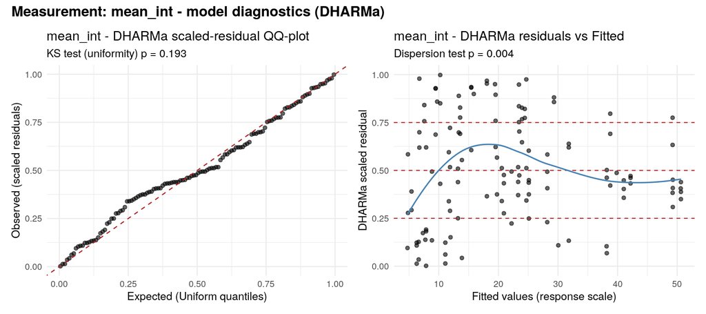

## 9. Fixed-effect significance

Type III test of the comparison-parameter effect for the final selected model per measurement. Satterthwaite F-test (Gaussian / Log-normal LMM) or Wald Chi-square test (Gamma GLMM), matching each family’s own convention.

| Measurement | Chisq | Df | p_value | Effect | pval_rounded | signif |
| --- | --- | --- | --- | --- | --- | --- |
| mean_int | 292.9529 | 7 | 0 | treatment_layer | <0.001 | *** |

## 10. Pairwise post-hoc comparisons

All pairwise contrasts between treatment groups from the final selected model, via `emmeans` - or, if `defined_contrasts` was supplied to `run_adaptive_model_selection_batch()`, only the explicitly requested comparisons (e.g. matched inner/middle/outer pairs rather than every possible pair). For Gamma GLMM / Log-normal LMM these are reported on the response scale (ratio of means / geometric means). P-values are adjusted for multiple comparisons across whichever set (all-pairs or defined) was actually run. Check Section 7 (scoring/audit log) for any requested comparison that had to be skipped because one of its levels wasn’t present for that particular measurement.

| Measurement | contrast | ratio | SE | df | null | z.ratio | p.value | pval_rounded | signif |
| --- | --- | --- | --- | --- | --- | --- | --- | --- | --- |
| mean_int | control_inner / laser_inner | 0.7163174 | 0.1024460 | Inf | 1 | -2.3328041 | 0.0393169 | 0.0393 | * |
| mean_int | control_middle / laser_middle | 0.6625398 | 0.0948050 | Inf | 1 | -2.8769655 | 0.0160608 | 0.0161 | * |
| mean_int | control_outer / laser_outer | 0.9992241 | 0.1449201 | Inf | 1 | -0.0053516 | 0.9957301 | 0.996 |  |
| mean_int | control_sum / laser_sum | 0.9446605 | 0.1364012 | Inf | 1 | -0.3942724 | 0.9245066 | 0.925 |  |

## 11. Random-effect variance components and ICC

Variance attributable to each grouping variable relative to total variance, for the final selected model per measurement.

| Measurement | Random_effect | Variance | Residual_var | ICC |
| --- | --- | --- | --- | --- |
| mean_int | ablation_id | 0.04751 | 0.15086 | 0.2395 |

## 12. Supplementary statistics table

| Measurement | Model_selected | N_total | Omnibus_stat_type | Omnibus_stat | Omnibus_df | Omnibus_p | Marginal_R2 | Conditional_R2 | ICC | Contrast | Effect_size | Effect_size_type | SE | Contrast_stat_type | Contrast_stat | Contrast_df | Contrast_p_adj | Signif | Caveat |
| --- | --- | --- | --- | --- | --- | --- | --- | --- | --- | --- | --- | --- | --- | --- | --- | --- | --- | --- | --- |
| mean_int | Gamma GLMM (Fixed slopes (random intercept only)) | 124 | Chisq | 292.953 | 7 | <0.001 | 0.6416 | 0.7322 | 0.2527 | control_inner / laser_inner | 0.7163 | ratio (response scale) | 0.1024 | z | -2.333 | NA | 0.0393 | * | NA |
| mean_int | Gamma GLMM (Fixed slopes (random intercept only)) | 124 | Chisq | 292.953 | 7 | <0.001 | 0.6416 | 0.7322 | 0.2527 | control_middle / laser_middle | 0.6625 | ratio (response scale) | 0.0948 | z | -2.877 | NA | 0.0161 | * | NA |
| mean_int | Gamma GLMM (Fixed slopes (random intercept only)) | 124 | Chisq | 292.953 | 7 | <0.001 | 0.6416 | 0.7322 | 0.2527 | control_outer / laser_outer | 0.9992 | ratio (response scale) | 0.1449 | z | -0.005 | NA | 0.996 |  | NA |
| mean_int | Gamma GLMM (Fixed slopes (random intercept only)) | 124 | Chisq | 292.953 | 7 | <0.001 | 0.6416 | 0.7322 | 0.2527 | control_sum / laser_sum | 0.9447 | ratio (response scale) | 0.1364 | z | -0.394 | NA | 0.925 |  | NA |

## Notes on interpretation

- **Candidates are excluded only for structural reasons** (failure to converge, singular fit, or - for a random-slopes rescue attempt - an inadequate group-count-to-parameter ratio). Poor residual diagnostics never exclude a candidate; they simply reduce its `residual_diagnostics` evidence contribution in Section 5. Biological datasets rarely produce textbook-perfect residual behaviour, so a candidate with imperfect but not-worst diagnostics can still win if it’s stronger elsewhere (R², stability, raw-data fit).
- **A measurement with only one non-excluded candidate** (e.g. Gaussian is the only structurally feasible option because the response isn’t strictly positive, or every alternative was singular) is “selected” by default - check Section 2 to see whether that’s actually a meaningful comparison or a fallback.
- **Random-slopes candidates** only appear in Sections 2-5 if a fixed-slope candidate of the same family failed its primary residual diagnostic (`alpha` in the batch call) AND the random-slopes refit converged, was non-singular, and had adequate group counts relative to its variance/covariance parameters. If a rescue attempt was tried and dropped, that’s logged in Section 7 (audit log) but the dropped candidate itself does not appear in Sections 2-5.
- **Missing/unavailable criteria** (e.g. Shapiro-Wilk not computed for n > 5000, or a DHARMa test failing to simulate) have their weight share redistributed among the remaining available criteria for that candidate, and a warning documenting this is recorded in Section 7 - check there if a candidate’s `Total_evidence` in Section 5 looks lower than expected.
- **The scoring weights are hard-coded** in `model_selection_weights` (`scoring.R`), not read from an external config - retuning them means editing that file directly (or passing an overriding `weights` list into `run_adaptive_model_selection_batch()` for a single run).